# 212-hw2

2025-02-03

# Q1

**from 4.2 we get:**：
$$p(X) = \frac{e^{\beta_0 + \beta_1 X}}{1 + e^{\beta_0 + \beta_1 X}}$$

**so we can get $1 - p(X)$ as**：
$$1 - p(X) = 1 - \frac{e^{\beta_0 + \beta_1 X}}{1 + e^{\beta_0 +
\beta_1 X}} = \frac{1}{1 + e^{\beta_0 + \beta_1 X}}.$$

**and get $\frac{p(X)}{1 - p(X)}$**：
$$\frac{p(X)}{1 - p(X)} = \frac{\frac{e^{\beta_0 + \beta_1 X}}{1 +
e^{\beta_0 + \beta_1 X}}}{\frac{1}{1 + e^{\beta_0 + \beta_1 X}}} =
e^{\beta_0 + \beta_1 X}.$$

**so we conclude**：
$$\frac{p(X)}{1 - p(X)} = e^{\beta_0 + \beta_1 X} \quad \square$$

# Q2

$$\begin{aligned}
z &= \hat{\beta}_0 + \hat{\beta}_1 X_1 + \hat{\beta}_2 X_2 \\
&= -6 + 0.05 \times 40 + 1 \times 3.5 \\
&= -0.5 \\
P(Y=1) &= \frac{1}{1 + e^{-z}} = \frac{1}{1 + e^{0.5}} \approx
\boxed{0.3775}
\end{aligned}$$
$$\begin{aligned}
0 &= -6 + 0.05 X_1 + 1 \times 3.5 \\
0.05 X_1 &= 2.5 \\
X_1 &= \frac{2.5}{0.05} = \boxed{50}
\end{aligned}$$

# Q3

## (a) Fraction of People Who Will Default

Given that the **odds** of defaulting on a credit card payment is 0.37, so calculate the probability $p$.

$$\text{Odds} = \frac{p}{1 - p}$$

Substituting the given value:

$$0.37 = \frac{p}{1 - p}$$

Solving for $p$:

$$p = 0.37 (1 - p)$$

$$p = 0.37 - 0.37p$$

$$p + 0.37p = 0.37$$

$$1.37p = 0.37$$

$$p = \frac{0.37}{1.37} \approx 0.27$$

Thus, approximately **27%** of people will default.

## (b) Calculating the Odds of Default

Given that the probability $p = 16\% = 0.16$, we calculate the **odds** using:

$$\text{Odds} = \frac{p}{1 - p}$$

$$\text{Odds} = \frac{0.16}{1 - 0.16} = \frac{0.16}{0.84} \approx 0.19$$

Thus, the **odds** of defaulting are **0.19** (or **19:100**)

# Q4

## a

```r
library(ISLR2)
data("Weekly")
summary(Weekly)
```

```
##       Year           Lag1               Lag2               Lag3
##  Min.   :1990   Min.   :-18.1950   Min.   :-18.1950   Min.   :-18.1950
##  1st Qu.:1995   1st Qu.: -1.1540   1st Qu.: -1.1540   1st Qu.: -1.1580
##  Median :2000   Median :  0.2410   Median :  0.2410   Median :  0.2410
##  Mean   :2000   Mean   :  0.1506   Mean   :  0.1511   Mean   :  0.1472
##  3rd Qu.:2005   3rd Qu.:  1.4050   3rd Qu.:  1.4090   3rd Qu.:  1.4090
##  Max.   :2010   Max.   : 12.0260   Max.   : 12.0260   Max.   : 12.0260
##       Lag4               Lag5              Volume            Today
##  Min.   :-18.1950   Min.   :-18.1950   Min.   :0.08747   Min.   :-18.1950
##  1st Qu.: -1.1580   1st Qu.: -1.1660   1st Qu.:0.33202   1st Qu.: -1.1540
##  Median :  0.2380   Median :  0.2340   Median :1.00268   Median :  0.2410
##  Mean   :  0.1458   Mean   :  0.1399   Mean   :1.57462   Mean   :  0.1499
##  3rd Qu.:  1.4090   3rd Qu.:  1.4050   3rd Qu.:2.05373   3rd Qu.:  1.4050
##  Max.   : 12.0260   Max.   : 12.0260   Max.   :9.32821   Max.   : 12.0260
##  Direction
##  Down:484
##  Up  :605
##
##
##
##
```

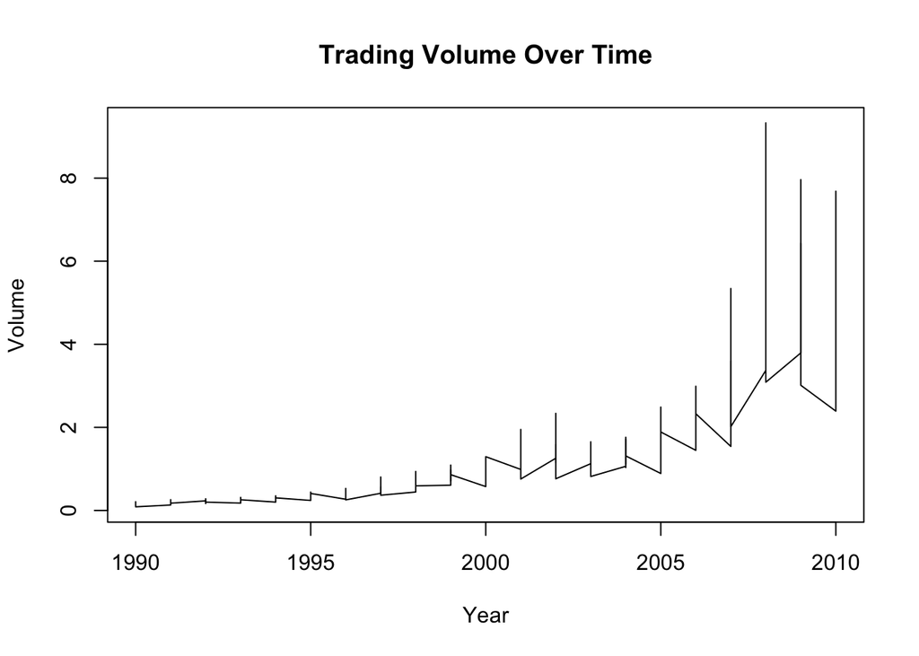

```r
# plot connected with time
plot(Weekly$Year, Weekly$Volume, type = "l",
     xlab = "Year", ylab = "Volume", main = "Trading Volume Over Time")
```

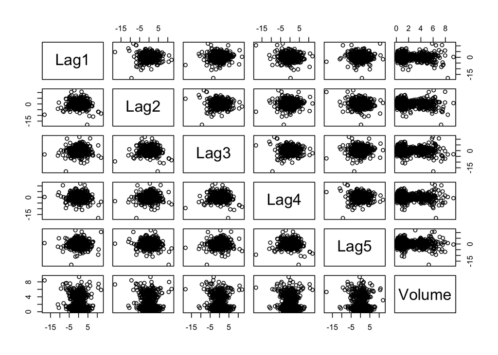

```r
pairs(~ Lag1 + Lag2 + Lag3 + Lag4 + Lag5 + Volume, data = Weekly)
```

## (b)

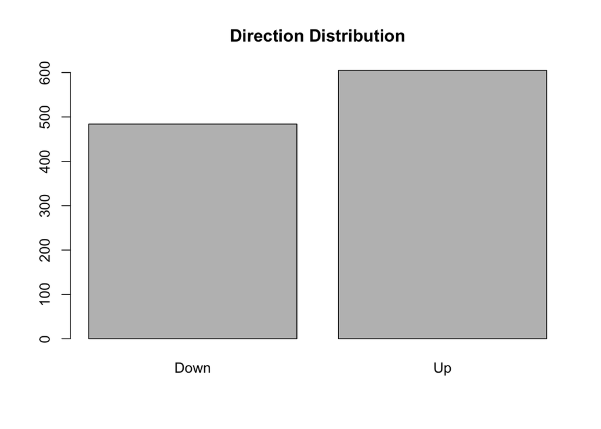

```r
# distribution
barplot(table(Weekly$Direction), main = "Direction Distribution")
```

```r
# generate model
model_logistic <- glm(Direction ~ Lag1 + Lag2 + Lag3 + Lag4 + Lag5 + Volume,
                data = Weekly, family = binomial)
summary(model_logistic)
```

```
##
## Call:
## glm(formula = Direction ~ Lag1 + Lag2 + Lag3 + Lag4 + Lag5 +
##     Volume, family = binomial, data = Weekly)
##
## Coefficients:
##             Estimate Std. Error z value Pr(>|z|)
## (Intercept)  0.26686    0.08593   3.106   0.0019 **
## Lag1        -0.04127    0.02641  -1.563   0.1181
## Lag2         0.05844    0.02686   2.175   0.0296 *
## Lag3        -0.01606    0.02666  -0.602   0.5469
## Lag4        -0.02779    0.02646  -1.050   0.2937
## Lag5        -0.01447    0.02638  -0.549   0.5833
## Volume      -0.02274    0.03690  -0.616   0.5377
## ---
## Signif. codes:  0 '***' 0.001 '**' 0.01 '*' 0.05 '.' 0.1 ' ' 1
##
## (Dispersion parameter for binomial family taken to be 1)
##
##     Null deviance: 1496.2  on 1088  degrees of freedom
## Residual deviance: 1486.4  on 1082  degrees of freedom
## AIC: 1500.4
##
## Number of Fisher Scoring iterations: 4
```

```r
logit_mod <- glm(
  Direction ~ Lag1 + Lag2 + Lag3 + Lag4 + Lag5 + Volume,
  family = binomial,
  data = Weekly
  )
summary(logit_mod)
```

```
##
## Call:
## glm(formula = Direction ~ Lag1 + Lag2 + Lag3 + Lag4 + Lag5 +
##     Volume, family = binomial, data = Weekly)
##
## Coefficients:
##             Estimate Std. Error z value Pr(>|z|)
## (Intercept)  0.26686    0.08593   3.106   0.0019 **
## Lag1        -0.04127    0.02641  -1.563   0.1181
## Lag2         0.05844    0.02686   2.175   0.0296 *
## Lag3        -0.01606    0.02666  -0.602   0.5469
## Lag4        -0.02779    0.02646  -1.050   0.2937
## Lag5        -0.01447    0.02638  -0.549   0.5833
## Volume      -0.02274    0.03690  -0.616   0.5377
## ---
## Signif. codes:  0 '***' 0.001 '**' 0.01 '*' 0.05 '.' 0.1 ' ' 1
##
## (Dispersion parameter for binomial family taken to be 1)
##
##     Null deviance: 1496.2  on 1088  degrees of freedom
## Residual deviance: 1486.4  on 1082  degrees of freedom
## AIC: 1500.4
##
## Number of Fisher Scoring iterations: 4
```

The p-value of Lag2 is 0.0296 which is less than 0.05, so we can reject the null hypothesis and conclude that Lag2 is statistical significant at 95% confidence level.

## (c)

```r
# if the probability higher than 0.5, marked as up, or is down
pred_full <- ifelse(predict(model_logistic, type = "response") > 0.5, "Up", "Down")
conf_matrix_full <- table(Predicted = pred_full, Actual = Weekly$Direction)
conf_matrix_full
```

```
##          Actual
## Predicted Down  Up
##      Down   54  48
##      Up    430 557
```

```r
# calculate rate
accuracy_full <- mean(pred_full == Weekly$Direction)
accuracy_full
```

```
## [1] 0.5610652
```

## (d)

```r
train <- Weekly$Year < 2009
Weekly_train <- Weekly[train, ]
Weekly_test <- Weekly[!train, ]
model_logistic <- glm(Direction ~ Lag2, data = Weekly_train, family = binomial)
# predict
logit_pred <- ifelse(predict(model_logistic, Weekly_test, type = "response") > 0.5, "Up", "Down")
conf_matrix_logistic <- table(Predicted = logit_pred, Actual = Weekly_test$Direction)
conf_matrix_logistic
```

```
##          Actual
## Predicted Down Up
##      Down    9  5
##      Up     34 56
```

```r
# calculate
accuracy_logistic <- mean(logit_pred == Weekly_test$Direction)
accuracy_logistic
```

```
## [1] 0.625
```

## (e)

```r
library(MASS)
model_lda <- lda(Direction ~ Lag2, data = Weekly_train)
pred_lda <- predict(model_lda, Weekly_test)
conf_matrix_lda <- table(Predicted = pred_lda$class, Actual = Weekly_test$Direction)
conf_matrix_lda
```

```
##          Actual
## Predicted Down Up
##      Down    9  5
##      Up     34 56
```

```r
accuracy_lda <- mean(pred_lda$class == Weekly_test$Direction)
accuracy_lda
```

```
## [1] 0.625
```

## (f)

```r
model_qda <- qda(Direction ~ Lag2, data = Weekly_train)
pred_qda <- predict(model_qda, Weekly_test)
conf_matrix_qda <- table(Predicted = pred_qda$class, Actual = Weekly_test$Direction)
conf_matrix_qda
```

```
##          Actual
## Predicted Down Up
##      Down    0  0
##      Up     43 61
```

```r
accuracy_qda <- mean(pred_qda$class == Weekly_test$Direction)
accuracy_qda
```

```
## [1] 0.5865385
```

## (g)

```r
library(class)
# name the data
train_X <- as.matrix(Weekly_train$Lag2)
test_X <- as.matrix(Weekly_test$Lag2)
train_direction <- Weekly_train$Direction

# use K = 1 to categorize for KNN
pred_knn <- knn(train_X, test_X, train_direction, k = 1)
conf_matrix_knn <- table(Predicted = pred_knn, Actual = Weekly_test$Direction)
conf_matrix_knn
```

```
##          Actual
## Predicted Down Up
##      Down   21 29
##      Up     22 32
```

```r
accuracy_knn <- mean(pred_knn == Weekly_test$Direction)
accuracy_knn
```

```
## [1] 0.5096154
```

## (h)

```r
library(e1071)
model_nb <- naiveBayes(Direction ~ Lag2, data = Weekly_train)
pred_nb <- predict(model_nb, Weekly_test)
conf_matrix_nb <- table(Predicted = pred_nb, Actual = Weekly_test$Direction)
conf_matrix_nb
```

```
##          Actual
## Predicted Down Up
##      Down    0  0
##      Up     43 61
```

```r
accuracy_nb <- mean(pred_nb == Weekly_test$Direction)
accuracy_nb
```

```
## [1] 0.5865385
```

## (i)

```r
library(pROC)
library(tibble)
library(MASS)
library(class)
library(e1071)
# model LDA
model_lda <- lda(Direction ~ Lag2, data = Weekly_train)
lda_pred <- predict(model_lda, Weekly_test)
lda_pred_prob <- lda_pred$posterior[, 2]
# model qda
model_qda <- qda(Direction ~ Lag2, data = Weekly_train)
qda_pred <- predict(model_qda, Weekly_test)
qda_pred_prob <- qda_pred$posterior[, 2]
# model nb
model_nb <- naiveBayes(Direction ~ Lag2, data = Weekly_train)
nb_pred_prob <- predict(model_nb, Weekly_test, type = "raw")[, 2]

library(class)
knn_train_matrix <- as.matrix(Weekly_train[, c("Lag2")])
knn_test_matrix <- as.matrix(Weekly_test[, c("Lag2")])

# train knn
knn_pred <- knn(
  train = knn_train_matrix,
  test = knn_test_matrix,
  cl = Weekly_train$Direction,
  prob = TRUE,
  k = 1
)

knn_pred_prob <- 1 - attr(knn_pred, "prob")
acc_f = function(cfm) {
  (cfm['Up', 'Up'] + cfm['Down', 'Down']) / sum(cfm)
}

fpr_f = function(cfm) {
  cfm['Up', 'Down'] / sum(cfm[, 'Down'])
}

fnr_f = function(cfm) {
  cfm['Down', 'Up'] / sum(cfm[, 'Up'])
}

auc_f = function(pred) {
  y = pred$y
  pred_prob = pred$prob
  roc_object <- roc(y, pred_prob)
  auc(roc_object)[1]
}
# probility
logistic_pred_prob <- predict(model_logistic, Weekly_test, type = "response")
lda_pred_prob <- lda_pred$posterior[, 2]
qda_pred_prob <- qda_pred$posterior[, 2]
nb_pred_prob <- predict(model_nb, Weekly_test, type = "raw")[, 2]

# KNN predict
knn_pred_prob <- 1 - attr(knn_pred, "prob")
conf_matrices <- list(
  Logistic = conf_matrix_logistic,
  LDA = conf_matrix_lda,
  QDA = conf_matrix_qda,
  NaiveBayes = conf_matrix_nb,
  KNN = conf_matrix_knn
)

# calculate ACC, FPR, FNR
acc_values <- sapply(conf_matrices, acc_f)
fpr_values <- sapply(conf_matrices, fpr_f)
fnr_values <- sapply(conf_matrices, fnr_f)

# calculate AUC
auc_values <- sapply(
  list(
    data.frame(y = Weekly_test$Direction, prob = logistic_pred_prob),
    data.frame(y = Weekly_test$Direction, prob = lda_pred_prob),
    data.frame(y = Weekly_test$Direction, prob = qda_pred_prob),
    data.frame(y = Weekly_test$Direction, prob = nb_pred_prob),
    data.frame(y = Weekly_test$Direction, prob = knn_pred_prob)
  ),
  auc_f
)
# make a tibble
model_performance <- tibble(
  Classifier = names(conf_matrices),
  Accuracy = acc_values,
  FPR = fpr_values,
  FNR = fnr_values,
  AUC = auc_values
)
print(model_performance)
```

```
## # A tibble: 5 × 5
##   Classifier Accuracy   FPR    FNR   AUC
##   <chr>         <dbl> <dbl>  <dbl> <dbl>
## 1 Logistic      0.625 0.791 0.0820 0.454
## 2 LDA           0.625 0.791 0.0820 0.454
## 3 QDA           0.587 1     0      0.491
## 4 NaiveBayes    0.587 1     0      0.491
## 5 KNN           0.510 0.512 0.475  0.513
```

## (j)

```r
Weekly_train$log_lag2 <- log(Weekly_train$Lag2/100 + 1)
Weekly_train$log_volume <- log(Weekly_train$Volume)
Weekly_test$log_lag2 <- log(Weekly_test$Lag2/100 + 1)
Weekly_test$log_volume <- log(Weekly_test$Volume)
# regression
model_logistic_combo <- glm(
  Direction ~ log_lag2 + log_volume + log_lag2:log_volume,
  data = Weekly_train,
  family = binomial
)

# predict
pred_test_combo <- ifelse(
  predict(model_logistic_combo, Weekly_test, type = "response") > 0.5,
  "Up",
  "Down"
)

conf_matrix_combo <- table(Predicted = pred_test_combo, Actual = Weekly_test$Direction)
accuracy_combo <- mean(pred_test_combo == Weekly_test$Direction)

# print
conf_matrix_combo
```

```
##          Actual
## Predicted Down Up
##      Down   15 15
##      Up     28 46
```

```r
accuracy_combo
```

```
## [1] 0.5865385
```

## Bonus question: ISL Exercise 4.8.4 (30pts)

**Answer:**

**(a)**  
Since X is uniformly distributed over [0, 1], the length of a 10% range on X is 0.1. This applies to any value of X, so the fraction of available observations is $\frac{0.1}{1} = 0.1$.

**(b)**  
Given that $(X_1, X_2)$ follows a uniform joint distribution on $[0, 1] \times [0, 1]$, a 10% interval on both $X_1$ and $X_2$ forms a square. This holds for any $(X_1, X_2)$, so the fraction of available observations is the area of the square divided by the total area, i.e., $\frac{0.1^2}{1^2} = 0.01$.

**(d)**  
As $p$ increases, the fraction of available observations decreases exponentially, meaning the training data “near” a given test observation becomes sparse. This sparsity means that exponentially more data is needed to cover the new volume. Without enough data, it becomes difficult to make reliable predictions because there aren’t enough samples in each local neighborhood. This is a drawback of the KNN model when $p$ is large.

**(e)**  
From the general formula $\frac{length^p}{1^p}$, we can derive that $length = \sqrt[p]{fraction}$.

- When $p = 1$, the length of the interval to include 10% of training observations is 0.1.
- When $p = 2$, the side length of the square to include 10% of training observations is $\sqrt[2]{0.1} \approx 0.32$.
- When $p = 100$, the side length of the hypercube to include 10% of training observations is $\sqrt[100]{0.1} \approx 0.98$.